# Direct-time integration solvers

Similarly to the previous section, the aim is to describe the direct time solvers available for solving Mdof systems. As a remainder, the equation of motion of the system is given by:
$$\mathbf{M} \ddot{\mathbf{x}}(t) + \mathbf{C} \dot{\mathbf{x}}(t) + \mathbf{K} \mathbf{x}(t) = \mathbf{F}(t)$$
where $\mathbf{M}$ is the mass matrix, $\mathbf{C}$ is the damping matrix, $\mathbf{K}$ is the stiffness matrix, $\mathbf{x}(t)$ is the displacement vector, and $\mathbf{F}(t)$ is the vector of external forces.

Direct-time integration solvers are used to solve the previous equation in the time domain. In Julia , we have the option of using [DifferentialEquations.jl](https://docs.sciml.ai/DiffEqDocs/stable/) which provides a wide range of solvers for solving differential equations.

The `StructuralVibration` package provides its own set of fixed-step linear second-order ODE solvers for pedagogical purposes and for the sake of completeness of the package. It should also be noted that some of the solvers implemented in the package are not available in [DiffentialEquations.jl](https://docs.sciml.ai/DiffEqDocs/stable/). This is the case of the solvers of the Newmark family, which are widely used in structural dynamics.

The solvers available in the `StructuralVibration` package are:

- Central difference method (CentralDiff)
- Fourth-order Runge-Kutta method (RK4)
- Newmark family solvers
  - Newmark-beta method (Newmark) [^1]
  - HHT method (HHT) [^2]
  - WBZ method (WBZ) [^3]
  - Fox-Goodwin method (FoxGoodwin) [^4]
  - Mid-Point rule (MidPoint) [^5]
  - Generalized-alpha method (GeneralizedAlpha) [^6]

## 1 API

**Data types**

**DirectTimeProblem**

```
DirectTimeProblem(K, M, C, F, u0, t)
DirectTimeProblem(K, M, C, u0, t)
```

Structure containing data for the time solver

**Constructor**

- `K::AbstractMatrix`: Stiffness matrix

- `M::AbstractMatrix`: Mass matrix

- `C:AbstractMatrix`: Damping matrix

- `F::AbstractMatrix`: External force matrix

- `u0::Tuple`: Initial conditions

  - `u0[1]`: Initial displacement (or modal displacement)

  - `u0[2]`: Initial velocity (or modal velocity)

- `t::AbstractVector`: Time points at which to evaluate the response

**Fields**

- `K`: Stiffness matrix

- `M`: Mass matrix

- `C`: Damping matrix

- `F`: External force matrix

- `u0`: Initial conditions

  - `u0[1]`: Initial displacement

  - `u0[2]`: Initial velocity

- `h::Real`: Time step

**Note**

- If `F` is not provided, it is assumed to be a zero matrix

**CentralDiff**

```
CentralDiff()
```

Central difference time solver

**RK4**

```
RK4()
```

Fourth-order Runge-Kutta time solver

**Newmark**

```
Newmark(; γ0 = 0.5, β0 = 0.25)
```

Newmark time solver

**HHT**

```
HHT(; γ0 = 0.5, β0 = 0.25, ρ = 1., αf = Inf)
```

Hilber-Hughes-Taylor time solver

**WBZ**

```
WBZ(; γ0 = 0.5, β0 = 0.25, ρ = 1., αm = Inf)
```

Wood-Bossak-Zienkiewicz time solver

**FoxGoodwin**

```
FoxGoodwin()
```

Fox-Goodwin time solver

**MidPoint**

```
MidPoint()
```

Mid-point rule time solver

**GeneralizedAlpha**

```
GeneralizedAlpha(; γ0 = 0.5, β0 = 0.25, ρ = 1., αf = Inf, αm = Inf)
```

Generalized-α time solver

**Related function**

**solve**

```
solve(prob::DirectTimeProblem, alg; progress = true)
```

Direct time integration solver

**Inputs**

- `prob`: DirectTimeProblem structure

- `alg`: Numerical integration algorithm

  - `CentralDiff()`: Central difference

  - `RK4()`: Fourth-order Runge-Kutta

  - `Newmark()`: Newmark

  - `HHT()`: Hilber-Hughes-Taylor

  - `WBZ()`: Wood-Bossak-Zienkiewicz

  - `GeneralizedAlpha()`: Generalized-α (default)

  - `MidPoint()`: Mid-point rule

- `progress`: Show progress bar

**Output**

- `sol`: Solution structure containing the response of the system at the given time points

  - `u`: Displacement

  - `du`: Velocity

  - `ddu`: Acceleration

## 2 Free response

The free response of a 2-dofs system is obtained by setting the external forces to zero. In this condition, the motion of the system is initiated by non-zero initial conditions. In the following example, the response provided by the direct time solvers is compared with the solution obtained by the modal solver described in [Modal time solvers - Section 1](https://maucejo.github.io/StructuralVibration.jl/solvers/modal_time_solvers.html) for the purpose of cross-validation.

```julia
using LinearAlgebra

# System parameters
M = Diagonal([2., 1.])
K = [6. -2.; -2. 4.]
ξ = 0.05

ω, Φ = eigenmode(K, M)
C = modal_damping_matrix(M, ω, ξ, Φ)

# Time vector
t = 0.:1e-2:30.

# Initial conditions
x0 = [0.2, 0.1]
v0 = zeros(2)
u0 = (x0, v0)

# External forces
F_free = zeros(2, length(t))

# Direct time problem
prob_free = DirectTimeProblem(K, M, C, F_free, u0, t)
x_free_gα = solve(prob_free).u
x_free_cd = solve(prob_free, CentralDiff()).u
x_free_rk = solve(prob_free, RK4()).u

# Modal time problem
prob_free_modal =  FreeModalTimeProblem(K, M, ξ, u0, t)
x_free_modal = solve(prob_free_modal).u
```

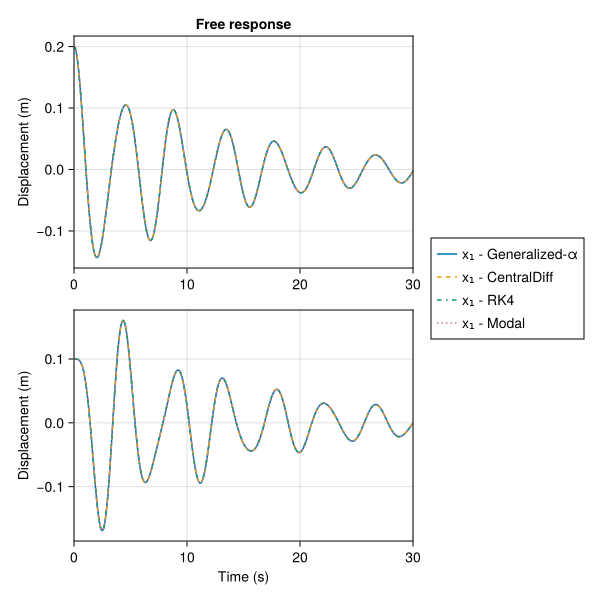

## 3 Forced response

The forced response of a 2-dofs system is obtained by applying a haversine excitation to the first dof of the system. As in the previous section, the response provided by the direct time solvers is compared with the solution obtained by the modal solver described in [Modal time solvers - Section 2](https://maucejo.github.io/StructuralVibration.jl/solvers/modal_time_solvers.html) for the purpose of cross-validation.

```julia
using LinearAlgebra

# System parameters
M = Diagonal([2., 1.])
K = [6. -2.; -2. 4.]
ξ = 0.05

ω, Φ = eigenmode(K, M)
C = modal_damping_matrix(M, ω, ξ, Φ)

# Time vector
t = 0.:1e-2:30.

# Initial conditions
x0 = zeros(2)
v0 = zeros(2)
u0 = (x0, v0)

# External forces
F0 = 10.
tstart = 2.
duration = 5.
haversine = HaverSine(F0, tstart, duration)
F0 = excitation(haversine, t)
F = zeros(2, length(t))
F[1, :] .= F0

# Direct time problem
prob_forced = DirectTimeProblem(K, M, C, F, u0, t)
x_forced_gα = solve(prob_forced).u
x_forced_cd = solve(prob_forced, CentralDiff()).u
x_forced_rk = solve(prob_forced, RK4()).u

# Modal time problem
prob_forced_modal = ForcedModalTimeProblem(K, M, ξ, F, u0, t)
x_forced_modal = solve(prob_forced_modal).u
```

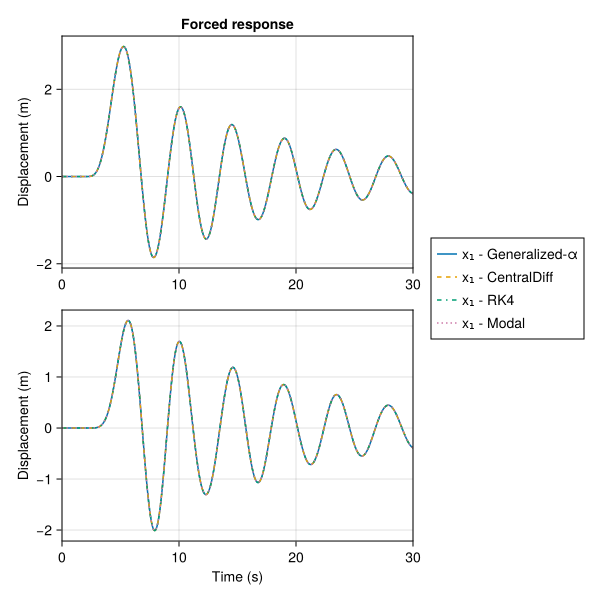

## 4 DifferentialEquations.jl solvers

This section illustrates how to use the [DifferentialEquations.jl](https://docs.sciml.ai/DiffEqDocs/stable/) solvers to solve problems discretized with the finite element method. The implementation is done using the `ODEProblem` from the `DifferentialEquations.jl` package.

### 4.1 Data preparation

```julia
L = 1.
b = 0.03
h = 0.01
S = b*h
I = b*h^3/12
E = 2.1e11
ρ = 7850.

# Initialization of the data types
beam = Beam(L, S, I, E, ρ)

# Mesh definition
oned_mesh = OneDMesh(beam, 0., 20, :SS)

# Construction of K and M
Kfe, Mfe = assembly(beam, oned_mesh)

# Application of the BCs
Kbc = apply_bc(Kfe, oned_mesh)
Mbc = apply_bc(Mfe, oned_mesh)
nddl = size(Kbc, 1)

# Calculation of the damping matrix
Cbc = rayleigh_damping_matrix(Kbc, Mbc, 1e-4, 5e-4)
```

### 4.2 Problem solution

```julia
# Time vector
t = 0.:1e-5:1.
nt = length(t)

# Initial conditions
x0 = 1e-3ones(nddl)
v0 = zeros(nddl)
u0 = (x0, v0)

# Direct time problem - Generalized-alpha method
prob = DirectTimeProblem(Kbc, Mbc, Cbc, u0, t)
u_gα = solve(prob).u
```

```julia
# To avoid name conflicts
import OrdinaryDiffEqTsit5 as DET
import OrdinaryDiffEqRosenbrock as DER

# First-order ODE function
function ode_solve!(du, u, p, t)
    A = p[1].Ac

    du .= A*u
end

u0 = [x0; v0]
css = ss_model(Kbc, Mbc, Cbc)
prob_ode = DET.ODEProblem(ode_solve!, u0, (t[1], t[end]), (css,))
sol_ode = DET.solve(prob_ode, DET.AutoTsit5(DER.Rosenbrock23()))
u_ode = sol_ode(t)[1:nddl, :]

# Second-order ODE function
function sde_solve!(ddu, du, u, p, t)
    M = p[1]
    K = p[2]
    C = p[3]

    ddu .= M\(-C*du .- K*u)
end

prob_sde = DET.SecondOrderODEProblem(sde_solve!, v0, x0, (t[1], t[end]), (Mbc, Kbc, Cbc))
sol_sde = DET.solve(prob_sde, DET.AutoTsit5(DER.Rosenbrock23()))
u_sde = sol_sde(t)[nddl+1:2*nddl, :]
```

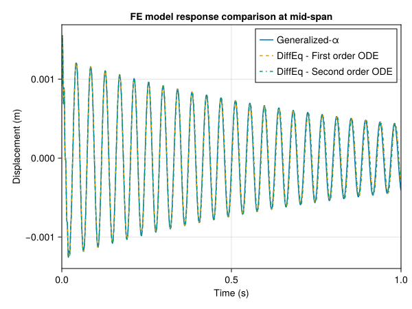

## Footnotes

[^1]: N. M. Newmark. “A method of computation for structural dynamics”. Journal of the Engineering Mechanics Division, 85(3), 67-94, 1959.
[^2]: H. M. Hilber, T. J. Hughes and R. L. Taylor. “Improved numerical dissipation for time integration algorithms in structural dynamics”. Earthquake Engineering & Structural Dynamics 5(3), 283–292. 1977.
[^3]: W. L. Wood, M. Bossak, O. Zienkiewicz. “An alpha modification of Newmark’s method”. International Journal for Numerical Methods in Engineering, 15(10), 1562-1566, 1980.
[^4]: L. Fox, E. T. Goodwin. “Some new methods for numerical integration of ordinary differential equations”. Mathematical Proceedings of the Cambridge Philosophical Society, 45(3), 373-388, 1949.
[^5]: M. Géradin and D. Rixen. “Mechanical Vibrations: Theory and Application to Structural Dynamics”. Third Edition. John Wiley & Sons, 2015.
[^6]: J. Chung and G. M. Hulbert. “A time integration algorithm for structural dynamics with improved numerical dissipation: the generalized-alpha method”. Journal of Applied Mechanics, 60(2), 371-375, 1993.